# Intermediate R Practice

William Surles

2017-07-04

> This document was updated on **2017-07-04**.

```r
library(dplyr)
```

# Introduction

- Course notes for [Intermediate R Practice](https://www.datacamp.com/courses/intermediate-r-practice)
- This course covers the topics from the Intermediate R class again
  - It focuses on application of the skills to answer questions about data
  - It feels a little forced in some cases as I would normally not use loops to analyze data
  - I would get my data out of list format first, as I will show here
  - But it is a really good review of the skills and I feel much more confident in the skills covered after this practice
  - If nothing else this course highlights how some of these skills can be very usefule, especially the regular expressions

## Whats Covered

- Conditionals and Control Flow
  - Relational Operators. `==` `<` `>`
  - Logical Operators. `&&` `||` `!`
  - Conditional Statements. `if` `else`
- While and For loops
- Functions
- Apply statements
  - lapply, sapply, vapply
- Utilities
  - Regular Expressions and grep/sub
  - Times and Dates

# Conditionals and Control Flow

- I have loaded the data into the notebook manually

```r
## my grade in the class (hypothetically)
me
```

```
## [1] 89
```

```r
## the other students grades
glimpse(other_199)
```

```
##  num [1:188] 66 81 77 90 95 54 78 90 71 96 ...
```

```r
## grades for students over the past 4 years
glimpse(previous_4)
```

```
##  int [1:200, 1:4] 82 66 66 86 76 74 56 80 71 69 ...
```

```r
head(previous_4)
```

```
##      [,1] [,2] [,3] [,4]
## [1,]   82   89   53   70
## [2,]   66   89   66   76
## [3,]   66   65   85   73
## [4,]   86   79   65   64
## [5,]   76   83   75   56
## [6,]   74   73   69   71
```

## Grades analysis in R

- First, we just join all the data to get a matrix of 5 years of data
- Normally there would be different numbers each year, but whatev

```r
# Merge me and other_199: my_class
my_class <- c(me, other_199)
head(my_class)
```

```
## [1] 89 66 81 77 90 95
```

```r
# cbind() my_class and previous_4: last_5
last_5 <- cbind(my_class, previous_4)
head(last_5)
```

```
##      my_class
## [1,]       89 82 89 53 70
## [2,]       66 66 89 66 76
## [3,]       81 66 65 85 73
## [4,]       77 86 79 65 64
## [5,]       90 76 83 75 56
## [6,]       95 74 73 69 71
```

```r
# Name last_5 appropriately
nms <- paste0("year_", 1:5)

colnames(last_5) <- nms
head(last_5)
```

```
##      year_1 year_2 year_3 year_4 year_5
## [1,]     89     82     89     53     70
## [2,]     66     66     89     66     76
## [3,]     81     66     65     85     73
## [4,]     77     86     79     65     64
## [5,]     90     76     83     75     56
## [6,]     95     74     73     69     71
```

## Explore your data

- There is an entire class on this later so this is just the start,
- These 3 functions are pretty useful

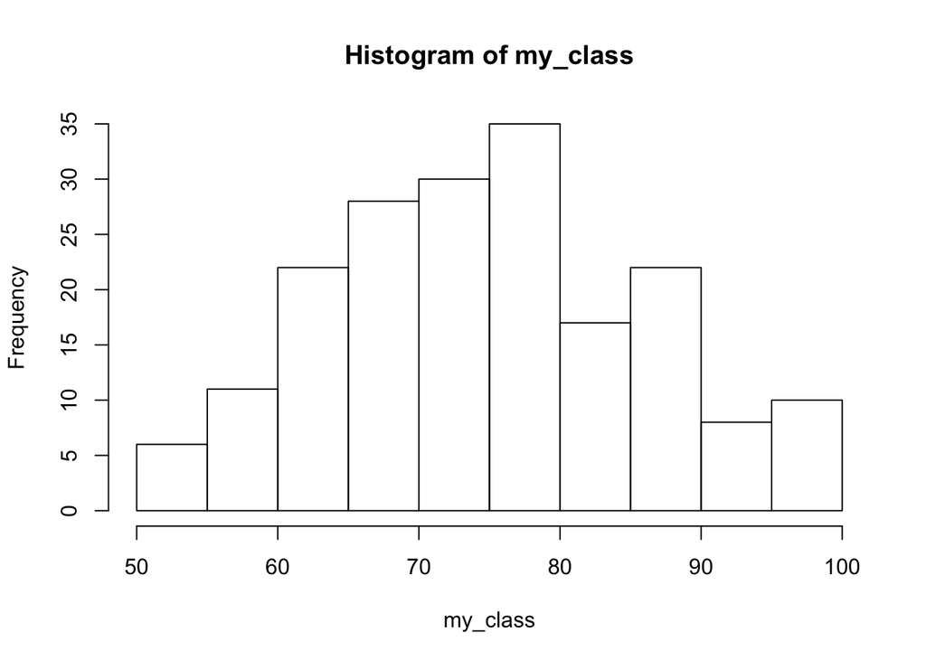

```r
# Build histogram of my_class
hist(my_class)
```

```r
# Generate summary of last_5
summary(last_5)
```

```
##      year_1           year_2           year_3           year_4           year_5
##  Min.   : 50.00   Min.   : 50.00   Min.   : 50.00   Min.   : 50.00   Min.   : 50.00
##  1st Qu.: 68.00   1st Qu.: 63.00   1st Qu.: 70.00   1st Qu.: 66.00   1st Qu.: 70.00
##  Median : 75.50   Median : 71.50   Median : 77.00   Median : 73.50   Median : 78.00
##  Mean   : 75.78   Mean   : 72.28   Mean   : 76.24   Mean   : 74.50   Mean   : 77.69
##  3rd Qu.: 83.25   3rd Qu.: 80.00   3rd Qu.: 84.00   3rd Qu.: 82.25   3rd Qu.: 88.00
##  Max.   :100.00   Max.   :100.00   Max.   :100.00   Max.   :100.00   Max.   :100.00
```

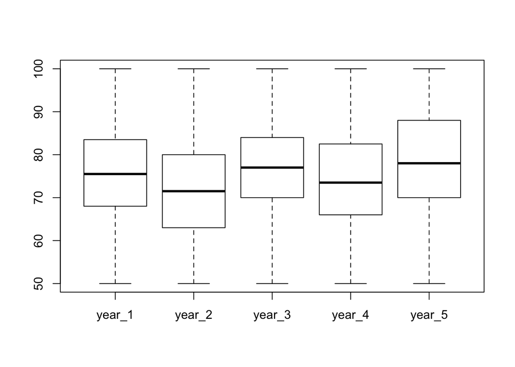

```r
# Build boxplot of last_5
boxplot(last_5)
```

## Basic queries

- This uses relational operators to answer very simple questions
- I am wrapping some of these in head, just to shorten the results

```r
# Is your grade equal to 72?
me == 72
```

```
## [1] FALSE
```

```r
# Which grades in your class are higher than 75?
head(my_class > 75, 10)
```

```
##  [1]  TRUE FALSE  TRUE  TRUE  TRUE  TRUE FALSE  TRUE  TRUE FALSE
```

```r
# Which grades in the last 5 years are below or equal to 64?
head(last_5 <= 64, 10)
```

```
##       year_1 year_2 year_3 year_4 year_5
##  [1,]  FALSE  FALSE  FALSE   TRUE  FALSE
##  [2,]  FALSE  FALSE  FALSE  FALSE  FALSE
##  [3,]  FALSE  FALSE  FALSE  FALSE  FALSE
##  [4,]  FALSE  FALSE  FALSE  FALSE   TRUE
##  [5,]  FALSE  FALSE  FALSE  FALSE   TRUE
##  [6,]  FALSE  FALSE  FALSE  FALSE  FALSE
##  [7,]   TRUE   TRUE  FALSE  FALSE  FALSE
##  [8,]  FALSE  FALSE  FALSE  FALSE  FALSE
##  [9,]  FALSE  FALSE   TRUE  FALSE  FALSE
## [10,]  FALSE  FALSE  FALSE  FALSE  FALSE
```

## Build aggregates

- Becuse the boolean arrays are only so useful. Normall a count or porportion is more helpful.

```r
# How many grades in your class are higher than 75?
sum(my_class > 75)
```

```
## [1] 92
```

```r
# How many students in your class scored strictly higher than you?
sum(my_class > me)
```

```
## [1] 26
```

```r
# What's the proportion of grades below or equal to 64 in the last 5 years?
mean(last_5 <= 64)
```

```
## [1] 0.2
```

## Logical operator

```r
# Is your grade greater than 87 and smaller than or equal to 89?
me > 87 & me <= 89
```

```
## [1] TRUE
```

```r
# Which grades in your class are below 60 or above 90?
head(my_class < 60 | my_class > 90, 20)
```

```
##  [1] FALSE FALSE FALSE FALSE FALSE  TRUE  TRUE FALSE FALSE FALSE  TRUE FALSE FALSE FALSE FALSE  TRUE
## [17] FALSE  TRUE FALSE  TRUE
```

## Build aggregates(2)

```r
# What's the proportion of grades in your class that is average?
mean(my_class >= 70 & my_class <= 85)
```

```
## [1] 0.5026455
```

```r
# How many students in the last 5 years had a grade of 80 or 90?
sum(last_5 == 80 | last_5 == 90)
```

```
## [1] 86
```

## if, else

```r
if (me > 80) {
  print("Good student!")
} else {
  print("Better luck next year!")
}
```

```
## [1] "Good student!"
```

## if, else: DIY

```r
# Define n_smart
n_smart <- sum(my_class >= 80)

# Code the if-else construct
if (n_smart > 50) {
  print("smart class")
} else {
  print("rather average")
}
```

```
## [1] "smart class"
```

## else if

```r
# Define prop_less
prop_less <- mean(my_class < me)

# Code the control construct
if(prop_less > .90) {
  print("you're among the best 10 percent")
} else if (prop_less > .80) {
  print("you're among the best 20 percent")
} else {
  print("need more analysis")
}
```

```
## [1] "you're among the best 20 percent"
```

## Embed if-else clauses

```r
# Embedded control structure: fix the error
if (mean(my_class) < 75) {
  if (mean(my_class) > me) {
    print("average year, but still smarter than me")
  } else {
    print("average year, but I'm not that bad")
  }
} else {
  if (mean(my_class) > me) {
    print("smart year, even smarter than me")
  } else {
    print("smart year, but I am smarter")
  }
}
```

```
## [1] "smart year, but I am smarter"
```

## Operations and controls expertise

```r
# Create top_grades
top_grades <- my_class[my_class >= 85]

# Create worst_grades
worst_grades <- my_class[my_class < 65]

# Write conditional statement
if (length(top_grades) > length(worst_grades)) {
  print("top grades prevail")
}
```

```
## [1] "top grades prevail"
```

# Loops

- I have loaded the data into the notebook manually
- logs has 96 entries
- showing the `str()` of logs will print the str of all entries
- I shorten here to save space

```r
length(logs)
```

```
## [1] 96
```

```r
logs[1:3]
```

```
## [[1]]
## [[1]]$success
## [1] TRUE
##
## [[1]]$details
## [[1]]$details$message
## [1] "check"
##
##
## [[1]]$timestamp
## [1] "2015-09-14 19:01:07 EDT"
##
##
## [[2]]
## [[2]]$success
## [1] TRUE
##
## [[2]]$details
## [[2]]$details$message
## [1] "all good"
##
##
## [[2]]$timestamp
## [1] "2015-09-14 20:00:13 EDT"
##
##
## [[3]]
## [[3]]$success
## [1] TRUE
##
## [[3]]$details
## [[3]]$details$message
## [1] "check"
##
##
## [[3]]$timestamp
## [1] "2015-09-14 21:00:43 EDT"
```

```r
str(logs[1:3])
```

```
## List of 3
##  $ :List of 3
##   ..$ success  : logi TRUE
##   ..$ details  :List of 1
##   .. ..$ message: chr "check"
##   ..$ timestamp: POSIXct[1:1], format: "2015-09-14 19:01:07"
##  $ :List of 3
##   ..$ success  : logi TRUE
##   ..$ details  :List of 1
##   .. ..$ message: chr "all good"
##   ..$ timestamp: POSIXct[1:1], format: "2015-09-14 20:00:13"
##  $ :List of 3
##   ..$ success  : logi TRUE
##   ..$ details  :List of 1
##   .. ..$ message: chr "check"
##   ..$ timestamp: POSIXct[1:1], format: "2015-09-14 21:00:43"
```

## Scanning Logs in R

```r
# Print the structure of logs
# str(logs)

# Use list subsetting to print the details part of 11th logs entry
logs[11]
```

```
## [[1]]
## [[1]]$success
## [1] TRUE
##
## [[1]]$details
## [[1]]$details$message
## [1] "ok"
##
##
## [[1]]$timestamp
## [1] "2015-09-15 04:59:54 EDT"
```

```r
# Print the class of the timestamp component of the first entry
class(logs[[1]]$timestamp)
```

```
## [1] "POSIXct" "POSIXt"
```

## Understand the logs

```r
## You can index into a list like this
logs[[2]][[2]][[1]]
```

```
## [1] "all good"
```

```r
## You can also use an array to index
logs[[c(2, 2, 1)]]
```

```
## [1] "all good"
```

```r
## Note that if success == FALSE then there are two elements in the details
```

## While: start easy

```r
# Initialize the iterator i to be 1
i <- 1

# Code the while loop
while ( logs[[i]]$success == TRUE ) {
  print(i)
  i <- i + 1
}
```

```
## [1] 1
## [1] 2
## [1] 3
## [1] 4
## [1] 5
## [1] 6
## [1] 7
## [1] 8
## [1] 9
```

## Adapt the while loop

```r
# Adapt the while loop
i <- 1
while (logs[[i]]$success) {
  print(logs[[i]]$details$message)
  i <- i + 1
}
```

```
## [1] "check"
## [1] "all good"
## [1] "check"
## [1] "check"
## [1] "ok"
## [1] "all good"
## [1] "check"
## [1] "all good"
## [1] "all good"
```

## While: different approach

- This approach set a value to false initially, then updates when a specific condition is met which will then top the loop

```r
# Initialize i and found
i <- 1
found <- FALSE

# Code the while loop
while (found == FALSE) {
  if (logs[[i]]$success == FALSE && logs[[i]]$details$location == "waste") {
    print("found")
    found <- TRUE
  } else {
    print("still looking")
    i <- i + 1
  }
}
```

```
## [1] "still looking"
## [1] "still looking"
## [1] "still looking"
## [1] "still looking"
## [1] "still looking"
## [1] "still looking"
## [1] "still looking"
## [1] "still looking"
## [1] "still looking"
## [1] "still looking"
## [1] "still looking"
## [1] "still looking"
## [1] "still looking"
## [1] "still looking"
## [1] "still looking"
## [1] "still looking"
## [1] "still looking"
## [1] "still looking"
## [1] "still looking"
## [1] "found"
```

## The for loop

- I shorten this up to just the first 10 logs

```r
# Code a for loop that prints the timestamp of each log
for (log in logs[1:10]) {
  print(log$timestamp)
}
```

```
## [1] "2015-09-14 19:01:07 EDT"
## [1] "2015-09-14 20:00:13 EDT"
## [1] "2015-09-14 21:00:43 EDT"
## [1] "2015-09-14 22:01:18 EDT"
## [1] "2015-09-14 22:59:59 EDT"
## [1] "2015-09-15 00:01:08 EDT"
## [1] "2015-09-15 01:03:20 EDT"
## [1] "2015-09-15 01:59:25 EDT"
## [1] "2015-09-15 02:59:29 EDT"
## [1] "2015-09-15 04:00:53 EDT"
```

## Going through the list

```r
# Make the printout conditional: only if success
for (log in logs[1:20]) {
  if (log$success == TRUE) {
    print(log$timestamp)
  }
}
```

```
## [1] "2015-09-14 19:01:07 EDT"
## [1] "2015-09-14 20:00:13 EDT"
## [1] "2015-09-14 21:00:43 EDT"
## [1] "2015-09-14 22:01:18 EDT"
## [1] "2015-09-14 22:59:59 EDT"
## [1] "2015-09-15 00:01:08 EDT"
## [1] "2015-09-15 01:03:20 EDT"
## [1] "2015-09-15 01:59:25 EDT"
## [1] "2015-09-15 02:59:29 EDT"
## [1] "2015-09-15 04:59:54 EDT"
## [1] "2015-09-15 06:00:39 EDT"
## [1] "2015-09-15 07:03:18 EDT"
## [1] "2015-09-15 08:01:49 EDT"
## [1] "2015-09-15 09:01:54 EDT"
## [1] "2015-09-15 10:02:27 EDT"
## [1] "2015-09-15 11:06:20 EDT"
## [1] "2015-09-15 12:05:48 EDT"
## [1] "2015-09-15 13:07:10 EDT"
```

## Adapt the logs list

```r
# Finish the for loop: add date element for each entry
for (i in 1:length(logs)) {
  logs[[i]]$date <- as.Date(logs[[i]]$timestamp)
}

# Print first 6 elements in logs
head(logs, 3)
```

```
## [[1]]
## [[1]]$success
## [1] TRUE
##
## [[1]]$details
## [[1]]$details$message
## [1] "check"
##
##
## [[1]]$timestamp
## [1] "2015-09-14 19:01:07 EDT"
##
## [[1]]$date
## [1] "2015-09-14"
##
##
## [[2]]
## [[2]]$success
## [1] TRUE
##
## [[2]]$details
## [[2]]$details$message
## [1] "all good"
##
##
## [[2]]$timestamp
## [1] "2015-09-14 20:00:13 EDT"
##
## [[2]]$date
## [1] "2015-09-15"
##
##
## [[3]]
## [[3]]$success
## [1] TRUE
##
## [[3]]$details
## [[3]]$details$message
## [1] "check"
##
##
## [[3]]$timestamp
## [1] "2015-09-14 21:00:43 EDT"
##
## [[3]]$date
## [1] "2015-09-15"
```

## Collect all failures

```r
# Intialize empty list: failures
failures <- list()

# Finish the for loop: add each failure to failures
for (log in logs) {
  if (log$success == FALSE) {
    failures <- c(failures, list(log))
  }
}

# Display the structure of failures
str(failures)
```

```
## List of 7
##  $ :List of 4
##   ..$ success  : logi FALSE
##   ..$ details  :List of 2
##   .. ..$ message : chr "stack overflow"
##   .. ..$ location: chr "control room"
##   ..$ timestamp: POSIXct[1:1], format: "2015-09-15 04:00:53"
##   ..$ date     : Date[1:1], format: "2015-09-15"
##  $ :List of 4
##   ..$ success  : logi FALSE
##   ..$ details  :List of 2
##   .. ..$ message : chr "segmentation fault"
##   .. ..$ location: chr "waste"
##   ..$ timestamp: POSIXct[1:1], format: "2015-09-15 14:07:58"
##   ..$ date     : Date[1:1], format: "2015-09-15"
##  $ :List of 4
##   ..$ success  : logi FALSE
##   ..$ details  :List of 2
##   .. ..$ message : chr "human error"
##   .. ..$ location: chr "reactor"
##   ..$ timestamp: POSIXct[1:1], format: "2015-09-15 17:14:16"
##   ..$ date     : Date[1:1], format: "2015-09-15"
##  $ :List of 4
##   ..$ success  : logi FALSE
##   ..$ details  :List of 2
##   .. ..$ message : chr "stack overflow"
##   .. ..$ location: chr "tubes"
##   ..$ timestamp: POSIXct[1:1], format: "2015-09-16 21:31:51"
##   ..$ date     : Date[1:1], format: "2015-09-17"
##  $ :List of 4
##   ..$ success  : logi FALSE
##   ..$ details  :List of 2
##   .. ..$ message : chr "segmentation fault"
##   .. ..$ location: chr "waste"
##   ..$ timestamp: POSIXct[1:1], format: "2015-09-17 09:33:43"
##   ..$ date     : Date[1:1], format: "2015-09-17"
##  $ :List of 4
##   ..$ success  : logi FALSE
##   ..$ details  :List of 2
##   .. ..$ message : chr "human error"
##   .. ..$ location: chr "waste"
##   ..$ timestamp: POSIXct[1:1], format: "2015-09-17 11:34:22"
##   ..$ date     : Date[1:1], format: "2015-09-17"
##  $ :List of 4
##   ..$ success  : logi FALSE
##   ..$ details  :List of 2
##   .. ..$ message : chr "human error"
##   .. ..$ location: chr "waste"
##   ..$ timestamp: POSIXct[1:1], format: "2015-09-17 23:37:18"
##   ..$ date     : Date[1:1], format: "2015-09-18"
```

## Without Loops

- The looping code above is good practice but normally you should not use loops in R.
- There are much better ways to work with data.
- I will show how to pull this list data into a dataframe to make life much easier while doing analysis.
- This is important because you can waste a lot of time not just in execution, but in writing code if you don’t learn `dplyr` and other libraries that are specifically made to crunch data.
- Loops are good for other programming routines or low level operations but not for crunching data.

### Pulling the list into a clean data frame

- Ideally the log data would be consistent and not have different elements in different situations.
- That makes it tricky to clean this up into a dataframe
- But its still possible and once clean is much easier to work with!
- Note: I am using the dplyr chain function to make these read well

Convert the variable level list to a dataframe:

- First, I convert each log into a data frame
  - I want to apply the `as.data.frame` function to each log record
  - I can’t name the columns here becasue `details.location` is not always present.
  - So, I will clean that up later
- Then you can use `bind_rows` (from `dplyr` package) to combine the list of dataframes
  - If the columns are missing in some of the dataframes (and they are) that is okay, it will just fill in with NA
- Now I will clean up the column names so `message` and `details.message` are the same column
  - I just set `details.message` to be `message` when its NA
  - I wish `as.data.frame` would always pull in the full name path from a list as the column name
  - Unfortunately, If there is just one nested record it will just use the last name as the column name, so we have `message` when its the only thing in details or `details.message` when there are multiple recoreds under details
  - This is lame but its how it works.
- And last thing is to remove the original `message` column since we have moved it into `details.message`

```r
df_logs <- logs %>%
  sapply(as.data.frame) %>%
  bind_rows() %>%
  mutate(
    details.message = ifelse(is.na(details.message), message, details.message)
  ) %>%
  select(-message)

head(df_logs, 12)
```

```
##    success           timestamp       date details.message details.location
## 1     TRUE 2015-09-14 19:01:07 2015-09-14           check             <NA>
## 2     TRUE 2015-09-14 20:00:13 2015-09-15        all good             <NA>
## 3     TRUE 2015-09-14 21:00:43 2015-09-15           check             <NA>
## 4     TRUE 2015-09-14 22:01:18 2015-09-15           check             <NA>
## 5     TRUE 2015-09-14 22:59:59 2015-09-15              ok             <NA>
## 6     TRUE 2015-09-15 00:01:08 2015-09-15        all good             <NA>
## 7     TRUE 2015-09-15 01:03:20 2015-09-15           check             <NA>
## 8     TRUE 2015-09-15 01:59:25 2015-09-15        all good             <NA>
## 9     TRUE 2015-09-15 02:59:29 2015-09-15        all good             <NA>
## 10   FALSE 2015-09-15 04:00:53 2015-09-15  stack overflow     control room
## 11    TRUE 2015-09-15 04:59:54 2015-09-15              ok             <NA>
## 12    TRUE 2015-09-15 06:00:39 2015-09-15              ok             <NA>
```

### Analysing the data

- Now we can see all the data so much easier.
- Really, you always want your data in a dataframe like this.
- These few lines of code pretty much cover all the tasks we just did with the loops above.

```r
## subset the data
df_logs %>% filter(success==FALSE)
```

```
##   success           timestamp       date    details.message details.location
## 1   FALSE 2015-09-15 04:00:53 2015-09-15     stack overflow     control room
## 2   FALSE 2015-09-15 14:07:58 2015-09-15 segmentation fault            waste
## 3   FALSE 2015-09-15 17:14:16 2015-09-15        human error          reactor
## 4   FALSE 2015-09-16 21:31:51 2015-09-17     stack overflow            tubes
## 5   FALSE 2015-09-17 09:33:43 2015-09-17 segmentation fault            waste
## 6   FALSE 2015-09-17 11:34:22 2015-09-17        human error            waste
## 7   FALSE 2015-09-17 23:37:18 2015-09-18        human error            waste
```

```r
df_logs %>% filter(success==FALSE & details.location == 'waste')
```

```
##   success           timestamp       date    details.message details.location
## 1   FALSE 2015-09-15 14:07:58 2015-09-15 segmentation fault            waste
## 2   FALSE 2015-09-17 09:33:43 2015-09-17 segmentation fault            waste
## 3   FALSE 2015-09-17 11:34:22 2015-09-17        human error            waste
## 4   FALSE 2015-09-17 23:37:18 2015-09-18        human error            waste
```

```r
## add data column
df_logs %>% mutate(date = as.Date(timestamp)) %>% head(10)
```

```
##    success           timestamp       date details.message details.location
## 1     TRUE 2015-09-14 19:01:07 2015-09-14           check             <NA>
## 2     TRUE 2015-09-14 20:00:13 2015-09-15        all good             <NA>
## 3     TRUE 2015-09-14 21:00:43 2015-09-15           check             <NA>
## 4     TRUE 2015-09-14 22:01:18 2015-09-15           check             <NA>
## 5     TRUE 2015-09-14 22:59:59 2015-09-15              ok             <NA>
## 6     TRUE 2015-09-15 00:01:08 2015-09-15        all good             <NA>
## 7     TRUE 2015-09-15 01:03:20 2015-09-15           check             <NA>
## 8     TRUE 2015-09-15 01:59:25 2015-09-15        all good             <NA>
## 9     TRUE 2015-09-15 02:59:29 2015-09-15        all good             <NA>
## 10   FALSE 2015-09-15 04:00:53 2015-09-15  stack overflow     control room
```

# Functions

- I have loaded the `timestamps` data into the notebook manually
- This is good practive for writting functions
- I should note that using dataframes instead of a list makes all of these next functions unnecessary
- Normall I use functions for more complex data conversions that I want to call from a dplyr chain
  - Or I may use a function to do a data crunching or charting process that I use often
- I don’t use functions to extract data. Just put it in a dataframe and you are good to go. : )

## Using functions

```r
# Call max() on timestamps
max(timestamps)
```

```
## [1] "2015-09-17 23:37:18 EDT"
```

```r
# What is the date of the latest timestamp?
as.Date(max(timestamps))
```

```
## [1] "2015-09-18"
```

## Optional Arguments

```r
# Print out timestamps
print(timestamps)
```

```
## [1] "2015-09-15 04:00:53 EDT" "2015-09-15 14:07:58 EDT" "2015-09-15 17:14:16 EDT"
## [4] "2015-09-16 21:31:51 EDT" "2015-09-17 09:33:43 EDT" "2015-09-17 11:34:22 EDT"
## [7] "2015-09-17 23:37:18 EDT"
```

```r
# Call max() on timestamps, no additional arguments
max(timestamps)
```

```
## [1] "2015-09-17 23:37:18 EDT"
```

```r
# Call max() on timestamps, specify na.rm
max(timestamps, na.rm=T)
```

```
## [1] "2015-09-17 23:37:18 EDT"
```

## Extracting log information (1)

```r
# Build a function extract_info(): use for loop, add return statement
extract_info <- function(x) {
  info <- c()
  for (log in x) {
    info <- c(info, log$timestamp)
  }
  return(info)
}

# Call extract_info() on logs
extract_info(logs)
```

```
##  [1] 1442271667 1442275213 1442278843 1442282479 1442286000 1442289669 1442293400 1442296766
##  [9] 1442300369 1442304054 1442307595 1442311239 1442314999 1442318509 1442322115 1442325748
## [17] 1442329581 1442333148 1442336831 1442340478 1442344104 1442347809 1442351656 1442355230
## [25] 1442358897 1442362565 1442366247 1442369825 1442373613 1442377367 1442381036 1442384587
## [33] 1442388127 1442391716 1442395201 1442398873 1442402487 1442406138 1442409894 1442413503
## [41] 1442416980 1442420588 1442424320 1442427945 1442431540 1442435144 1442438737 1442442497
## [49] 1442446129 1442449737 1442453512 1442457227 1442460737 1442464501 1442468239 1442471721
## [57] 1442475370 1442478869 1442482442 1442486000 1442489681 1442493222 1442496823 1442500519
## [65] 1442504062 1442507676 1442511301 1442514920 1442518449 1442522024 1442525547 1442529154
## [73] 1442532866 1442536496 1442540274 1442543775 1442547438 1442550882 1442554480 1442558131
## [81] 1442561734 1442565493 1442569141 1442572776 1442576398 1442580077 1442583672 1442587330
## [89] 1442591011 1442594690 1442598327 1442602124 1442605778 1442609424 1442613054 1442616469
```

## Extracting log information (2)

```r
# Adapt the extract_info() function.
extract_info <- function(x, property) {

  info <- c()

  for (log in x) {
   info <- c(info, log[[property]])
  }

  return(info)
}

# Call extract_info() on logs, set property to "timestamp"
extract_info(logs, "timestamp")
```

```
##  [1] 1442271667 1442275213 1442278843 1442282479 1442286000 1442289669 1442293400 1442296766
##  [9] 1442300369 1442304054 1442307595 1442311239 1442314999 1442318509 1442322115 1442325748
## [17] 1442329581 1442333148 1442336831 1442340478 1442344104 1442347809 1442351656 1442355230
## [25] 1442358897 1442362565 1442366247 1442369825 1442373613 1442377367 1442381036 1442384587
## [33] 1442388127 1442391716 1442395201 1442398873 1442402487 1442406138 1442409894 1442413503
## [41] 1442416980 1442420588 1442424320 1442427945 1442431540 1442435144 1442438737 1442442497
## [49] 1442446129 1442449737 1442453512 1442457227 1442460737 1442464501 1442468239 1442471721
## [57] 1442475370 1442478869 1442482442 1442486000 1442489681 1442493222 1442496823 1442500519
## [65] 1442504062 1442507676 1442511301 1442514920 1442518449 1442522024 1442525547 1442529154
## [73] 1442532866 1442536496 1442540274 1442543775 1442547438 1442550882 1442554480 1442558131
## [81] 1442561734 1442565493 1442569141 1442572776 1442576398 1442580077 1442583672 1442587330
## [89] 1442591011 1442594690 1442598327 1442602124 1442605778 1442609424 1442613054 1442616469
```

```r
# Call extract_info() on logs, set property to "success"
extract_info(logs, "success")
```

```
##  [1]  TRUE  TRUE  TRUE  TRUE  TRUE  TRUE  TRUE  TRUE  TRUE FALSE  TRUE  TRUE  TRUE  TRUE  TRUE  TRUE
## [17]  TRUE  TRUE  TRUE FALSE  TRUE  TRUE FALSE  TRUE  TRUE  TRUE  TRUE  TRUE  TRUE  TRUE  TRUE  TRUE
## [33]  TRUE  TRUE  TRUE  TRUE  TRUE  TRUE  TRUE  TRUE  TRUE  TRUE  TRUE  TRUE  TRUE  TRUE  TRUE  TRUE
## [49]  TRUE  TRUE FALSE  TRUE  TRUE  TRUE  TRUE  TRUE  TRUE  TRUE  TRUE  TRUE  TRUE  TRUE FALSE  TRUE
## [65] FALSE  TRUE  TRUE  TRUE  TRUE  TRUE  TRUE  TRUE  TRUE  TRUE  TRUE  TRUE FALSE  TRUE  TRUE  TRUE
## [81]  TRUE  TRUE  TRUE  TRUE  TRUE  TRUE  TRUE  TRUE  TRUE  TRUE  TRUE  TRUE  TRUE  TRUE  TRUE  TRUE
```

## Extracting log information (3)

```r
# Add default value for property argument
extract_info <- function(x, property="success") {
  info <- c()
  for (log in x) {
   info <- c(info, log[[property]])
  }
  return(info)
}

# Call extract_info() on logs, don't specify property
extract_info(logs)
```

```
##  [1]  TRUE  TRUE  TRUE  TRUE  TRUE  TRUE  TRUE  TRUE  TRUE FALSE  TRUE  TRUE  TRUE  TRUE  TRUE  TRUE
## [17]  TRUE  TRUE  TRUE FALSE  TRUE  TRUE FALSE  TRUE  TRUE  TRUE  TRUE  TRUE  TRUE  TRUE  TRUE  TRUE
## [33]  TRUE  TRUE  TRUE  TRUE  TRUE  TRUE  TRUE  TRUE  TRUE  TRUE  TRUE  TRUE  TRUE  TRUE  TRUE  TRUE
## [49]  TRUE  TRUE FALSE  TRUE  TRUE  TRUE  TRUE  TRUE  TRUE  TRUE  TRUE  TRUE  TRUE  TRUE FALSE  TRUE
## [65] FALSE  TRUE  TRUE  TRUE  TRUE  TRUE  TRUE  TRUE  TRUE  TRUE  TRUE  TRUE FALSE  TRUE  TRUE  TRUE
## [81]  TRUE  TRUE  TRUE  TRUE  TRUE  TRUE  TRUE  TRUE  TRUE  TRUE  TRUE  TRUE  TRUE  TRUE  TRUE  TRUE
```

```r
# Call extract_info() on logs, set property to "timestamp"
extract_info(logs, "timestamp")
```

```
##  [1] 1442271667 1442275213 1442278843 1442282479 1442286000 1442289669 1442293400 1442296766
##  [9] 1442300369 1442304054 1442307595 1442311239 1442314999 1442318509 1442322115 1442325748
## [17] 1442329581 1442333148 1442336831 1442340478 1442344104 1442347809 1442351656 1442355230
## [25] 1442358897 1442362565 1442366247 1442369825 1442373613 1442377367 1442381036 1442384587
## [33] 1442388127 1442391716 1442395201 1442398873 1442402487 1442406138 1442409894 1442413503
## [41] 1442416980 1442420588 1442424320 1442427945 1442431540 1442435144 1442438737 1442442497
## [49] 1442446129 1442449737 1442453512 1442457227 1442460737 1442464501 1442468239 1442471721
## [57] 1442475370 1442478869 1442482442 1442486000 1442489681 1442493222 1442496823 1442500519
## [65] 1442504062 1442507676 1442511301 1442514920 1442518449 1442522024 1442525547 1442529154
## [73] 1442532866 1442536496 1442540274 1442543775 1442547438 1442550882 1442554480 1442558131
## [81] 1442561734 1442565493 1442569141 1442572776 1442576398 1442580077 1442583672 1442587330
## [89] 1442591011 1442594690 1442598327 1442602124 1442605778 1442609424 1442613054 1442616469
```

## Extracting log information (4)

```r
# Adapt extract_info():
# - add argument with default value
# - change function body
extract_info <- function(x, property = "success", include_all=T) {
  info <- c()
  for (log in x) {

   # add if construct around the line below
   if (include_all || !log$success) {

      info <- c(info, log[[property]])

    }

  }
  return(info)
}

# Call extract_info() on logs, no additional arguments
extract_info(logs)
```

```
##  [1]  TRUE  TRUE  TRUE  TRUE  TRUE  TRUE  TRUE  TRUE  TRUE FALSE  TRUE  TRUE  TRUE  TRUE  TRUE  TRUE
## [17]  TRUE  TRUE  TRUE FALSE  TRUE  TRUE FALSE  TRUE  TRUE  TRUE  TRUE  TRUE  TRUE  TRUE  TRUE  TRUE
## [33]  TRUE  TRUE  TRUE  TRUE  TRUE  TRUE  TRUE  TRUE  TRUE  TRUE  TRUE  TRUE  TRUE  TRUE  TRUE  TRUE
## [49]  TRUE  TRUE FALSE  TRUE  TRUE  TRUE  TRUE  TRUE  TRUE  TRUE  TRUE  TRUE  TRUE  TRUE FALSE  TRUE
## [65] FALSE  TRUE  TRUE  TRUE  TRUE  TRUE  TRUE  TRUE  TRUE  TRUE  TRUE  TRUE FALSE  TRUE  TRUE  TRUE
## [81]  TRUE  TRUE  TRUE  TRUE  TRUE  TRUE  TRUE  TRUE  TRUE  TRUE  TRUE  TRUE  TRUE  TRUE  TRUE  TRUE
```

```r
# Call extract_info() on logs, set include_all to FALSE
extract_info(logs, include_all=F)
```

```
## [1] FALSE FALSE FALSE FALSE FALSE FALSE FALSE
```

## Extracting log information (5)

```r
# Defition of the extract_info() function
extract_info <- function(x, property = "success", include_all = TRUE) {
  info <- c()
  for (log in x) {
    if (include_all || !log$success) {
     info <- c(info, log[[property]])
    }
  }
  return(info)
}

# Generate vector of messages
extract_info(logs, property = c('details', 'message'))
```

```
##  [1] "check"              "all good"           "check"              "check"
##  [5] "ok"                 "all good"           "check"              "all good"
##  [9] "all good"           "stack overflow"     "ok"                 "ok"
## [13] "all good"           "check"              "check"              "ok"
## [17] "check"              "check"              "all good"           "segmentation fault"
## [21] "check"              "all good"           "human error"        "check"
## [25] "ok"                 "all good"           "check"              "ok"
## [29] "ok"                 "all good"           "ok"                 "ok"
## [33] "ok"                 "ok"                 "check"              "all good"
## [37] "ok"                 "ok"                 "ok"                 "ok"
## [41] "ok"                 "ok"                 "check"              "all good"
## [45] "all good"           "check"              "check"              "check"
## [49] "check"              "check"              "stack overflow"     "ok"
## [53] "ok"                 "all good"           "check"              "ok"
## [57] "check"              "ok"                 "check"              "ok"
## [61] "ok"                 "ok"                 "segmentation fault" "check"
## [65] "human error"        "ok"                 "ok"                 "all good"
## [69] "ok"                 "all good"           "check"              "check"
## [73] "ok"                 "check"              "all good"           "ok"
## [77] "human error"        "ok"                 "check"              "all good"
## [81] "check"              "check"              "check"              "check"
## [85] "check"              "ok"                 "ok"                 "all good"
## [89] "ok"                 "all good"           "all good"           "all good"
## [93] "all good"           "ok"                 "check"              "check"
```

```r
# Generate vector of locations for failed log entries
extract_info(logs, property = c('details','location'), include_all = F)
```

```
## [1] "control room" "waste"        "reactor"      "tubes"        "waste"        "waste"
## [7] "waste"
```

## Over to you

```r
# Write the function compute_fail_pct

compute_fail_pct <- function(logs) {

  is_fail <- c()

  for (i in 1:length(logs)) {
    is_fail[i] <- logs[[i]]$success == FALSE
  }

  fail_pct <- sum(is_fail)/length(is_fail) * 100

  return(fail_pct)
}


# Call compute_fail_pct on logs
compute_fail_pct(logs)
```

```
## [1] 7.291667
```

# The apply family

- I have rarely use the apply family after learning dplyr
- But there are some times when its helpful, like above where I used it to convert the list elements to a dataframe before row binding them
- These are also good to know because you may need to do some data crunching in another language and this would be a good pattern to follow if they have a `map` function or something like the `apply` functions.

## lapply refresher

```r
# Call length() on each element of logs
lapply(logs,length) %>% head()
```

```
## [[1]]
## [1] 4
##
## [[2]]
## [1] 4
##
## [[3]]
## [1] 4
##
## [[4]]
## [1] 4
##
## [[5]]
## [1] 4
##
## [[6]]
## [1] 4
```

```r
# Call class() on each element of logs
lapply(logs,class) %>% head()
```

```
## [[1]]
## [1] "list"
##
## [[2]]
## [1] "list"
##
## [[3]]
## [1] "list"
##
## [[4]]
## [1] "list"
##
## [[5]]
## [1] "list"
##
## [[6]]
## [1] "list"
```

## lapply on logs (1)

```r
# Define get_timestamp()
get_timestamp <- function(x) {
  return(x$timestamp)
}

# Apply get_timestamp() over all elements in logs
lapply(logs, get_timestamp) %>% head()
```

```
## [[1]]
## [1] "2015-09-14 19:01:07 EDT"
##
## [[2]]
## [1] "2015-09-14 20:00:13 EDT"
##
## [[3]]
## [1] "2015-09-14 21:00:43 EDT"
##
## [[4]]
## [1] "2015-09-14 22:01:18 EDT"
##
## [[5]]
## [1] "2015-09-14 22:59:59 EDT"
##
## [[6]]
## [1] "2015-09-15 00:01:08 EDT"
```

## lapply on logs (2)

```r
# Have lapply() use an anonymous function
lapply(logs, function(x) {x$timestamp}) %>% head()
```

```
## [[1]]
## [1] "2015-09-14 19:01:07 EDT"
##
## [[2]]
## [1] "2015-09-14 20:00:13 EDT"
##
## [[3]]
## [1] "2015-09-14 21:00:43 EDT"
##
## [[4]]
## [1] "2015-09-14 22:01:18 EDT"
##
## [[5]]
## [1] "2015-09-14 22:59:59 EDT"
##
## [[6]]
## [1] "2015-09-15 00:01:08 EDT"
```

## lapply on logs (3)

```r
# Replace the anonymous function with `[[`
lapply(logs, `[[`, 'timestamp') %>% head()
```

```
## [[1]]
## [1] "2015-09-14 19:01:07 EDT"
##
## [[2]]
## [1] "2015-09-14 20:00:13 EDT"
##
## [[3]]
## [1] "2015-09-14 21:00:43 EDT"
##
## [[4]]
## [1] "2015-09-14 22:01:18 EDT"
##
## [[5]]
## [1] "2015-09-14 22:59:59 EDT"
##
## [[6]]
## [1] "2015-09-15 00:01:08 EDT"
```

## sapply refresher

```r
# Call length() on each element of logs using sapply()
sapply(logs, length)
```

```
##  [1] 4 4 4 4 4 4 4 4 4 4 4 4 4 4 4 4 4 4 4 4 4 4 4 4 4 4 4 4 4 4 4 4 4 4 4 4 4 4 4 4 4 4 4 4 4 4 4 4
## [49] 4 4 4 4 4 4 4 4 4 4 4 4 4 4 4 4 4 4 4 4 4 4 4 4 4 4 4 4 4 4 4 4 4 4 4 4 4 4 4 4 4 4 4 4 4 4 4 4
```

```r
# Definition of get_timestamp
get_timestamp <- function(x) {
  x$timestamp
}

# Get vector of log entries' timestamps
sapply(logs, get_timestamp)
```

```
##  [1] 1442271667 1442275213 1442278843 1442282479 1442286000 1442289669 1442293400 1442296766
##  [9] 1442300369 1442304054 1442307595 1442311239 1442314999 1442318509 1442322115 1442325748
## [17] 1442329581 1442333148 1442336831 1442340478 1442344104 1442347809 1442351656 1442355230
## [25] 1442358897 1442362565 1442366247 1442369825 1442373613 1442377367 1442381036 1442384587
## [33] 1442388127 1442391716 1442395201 1442398873 1442402487 1442406138 1442409894 1442413503
## [41] 1442416980 1442420588 1442424320 1442427945 1442431540 1442435144 1442438737 1442442497
## [49] 1442446129 1442449737 1442453512 1442457227 1442460737 1442464501 1442468239 1442471721
## [57] 1442475370 1442478869 1442482442 1442486000 1442489681 1442493222 1442496823 1442500519
## [65] 1442504062 1442507676 1442511301 1442514920 1442518449 1442522024 1442525547 1442529154
## [73] 1442532866 1442536496 1442540274 1442543775 1442547438 1442550882 1442554480 1442558131
## [81] 1442561734 1442565493 1442569141 1442572776 1442576398 1442580077 1442583672 1442587330
## [89] 1442591011 1442594690 1442598327 1442602124 1442605778 1442609424 1442613054 1442616469
```

## sapply on logs (1)

```r
# Use sapply() to select the success element from each log: results
results <- sapply(logs, `[[`, 'success')

# Call mean() on results
mean(results)
```

```
## [1] 0.9270833
```

```r
# Use sapply() to select the details element from each log
sapply(logs, `[[`, 'details') %>% head()
```

```
## [[1]]
## [[1]]$message
## [1] "check"
##
##
## [[2]]
## [[2]]$message
## [1] "all good"
##
##
## [[3]]
## [[3]]$message
## [1] "check"
##
##
## [[4]]
## [[4]]$message
## [1] "check"
##
##
## [[5]]
## [[5]]$message
## [1] "ok"
##
##
## [[6]]
## [[6]]$message
## [1] "all good"
```

## sapply on logs (2)

```r
# Implement function get_failure_loc
get_failure_loc <- function(x) {
  if (x$success==T) {
    return(NULL)
  } else {
    return(x$details$location)
  }
}

# Use sapply() to call get_failure_loc on logs
sapply(logs, get_failure_loc) %>% head(11)
```

```
## [[1]]
## NULL
##
## [[2]]
## NULL
##
## [[3]]
## NULL
##
## [[4]]
## NULL
##
## [[5]]
## NULL
##
## [[6]]
## NULL
##
## [[7]]
## NULL
##
## [[8]]
## NULL
##
## [[9]]
## NULL
##
## [[10]]
## [1] "control room"
##
## [[11]]
## NULL
```

## vapply refresher

```r
# Convert the sapply call to vapply
vapply(logs, length, integer(1))
```

```
##  [1] 4 4 4 4 4 4 4 4 4 4 4 4 4 4 4 4 4 4 4 4 4 4 4 4 4 4 4 4 4 4 4 4 4 4 4 4 4 4 4 4 4 4 4 4 4 4 4 4
## [49] 4 4 4 4 4 4 4 4 4 4 4 4 4 4 4 4 4 4 4 4 4 4 4 4 4 4 4 4 4 4 4 4 4 4 4 4 4 4 4 4 4 4 4 4 4 4 4 4
```

```r
# Convert the sapply call to vapply
vapply(logs, `[[`, "success", FUN.VALUE = logical(1))
```

```
##  [1]  TRUE  TRUE  TRUE  TRUE  TRUE  TRUE  TRUE  TRUE  TRUE FALSE  TRUE  TRUE  TRUE  TRUE  TRUE  TRUE
## [17]  TRUE  TRUE  TRUE FALSE  TRUE  TRUE FALSE  TRUE  TRUE  TRUE  TRUE  TRUE  TRUE  TRUE  TRUE  TRUE
## [33]  TRUE  TRUE  TRUE  TRUE  TRUE  TRUE  TRUE  TRUE  TRUE  TRUE  TRUE  TRUE  TRUE  TRUE  TRUE  TRUE
## [49]  TRUE  TRUE FALSE  TRUE  TRUE  TRUE  TRUE  TRUE  TRUE  TRUE  TRUE  TRUE  TRUE  TRUE FALSE  TRUE
## [65] FALSE  TRUE  TRUE  TRUE  TRUE  TRUE  TRUE  TRUE  TRUE  TRUE  TRUE  TRUE FALSE  TRUE  TRUE  TRUE
## [81]  TRUE  TRUE  TRUE  TRUE  TRUE  TRUE  TRUE  TRUE  TRUE  TRUE  TRUE  TRUE  TRUE  TRUE  TRUE  TRUE
```

## vapply on logs (1)

```r
# Convert the sapply() call to a vapply() or lapply() call
vapply(logs, `[[`, c("details", "message"), FUN.VALUE=character(1))
```

```
##  [1] "check"              "all good"           "check"              "check"
##  [5] "ok"                 "all good"           "check"              "all good"
##  [9] "all good"           "stack overflow"     "ok"                 "ok"
## [13] "all good"           "check"              "check"              "ok"
## [17] "check"              "check"              "all good"           "segmentation fault"
## [21] "check"              "all good"           "human error"        "check"
## [25] "ok"                 "all good"           "check"              "ok"
## [29] "ok"                 "all good"           "ok"                 "ok"
## [33] "ok"                 "ok"                 "check"              "all good"
## [37] "ok"                 "ok"                 "ok"                 "ok"
## [41] "ok"                 "ok"                 "check"              "all good"
## [45] "all good"           "check"              "check"              "check"
## [49] "check"              "check"              "stack overflow"     "ok"
## [53] "ok"                 "all good"           "check"              "ok"
## [57] "check"              "ok"                 "check"              "ok"
## [61] "ok"                 "ok"                 "segmentation fault" "check"
## [65] "human error"        "ok"                 "ok"                 "all good"
## [69] "ok"                 "all good"           "check"              "check"
## [73] "ok"                 "check"              "all good"           "ok"
## [77] "human error"        "ok"                 "check"              "all good"
## [81] "check"              "check"              "check"              "check"
## [85] "check"              "ok"                 "ok"                 "all good"
## [89] "ok"                 "all good"           "all good"           "all good"
## [93] "all good"           "ok"                 "check"              "check"
```

```r
# Convert the sapply() call to a vapply() or lapply() call
lapply(logs, function(x) { x$details }) %>% head()
```

```
## [[1]]
## [[1]]$message
## [1] "check"
##
##
## [[2]]
## [[2]]$message
## [1] "all good"
##
##
## [[3]]
## [[3]]$message
## [1] "check"
##
##
## [[4]]
## [[4]]$message
## [1] "check"
##
##
## [[5]]
## [[5]]$message
## [1] "ok"
##
##
## [[6]]
## [[6]]$message
## [1] "all good"
```

## loop it the way you want it

```r
# Return vector with uppercase version of message elements in log entries
toupper(sapply(logs, `[[`, c('details','message')))
```

```
##  [1] "CHECK"              "ALL GOOD"           "CHECK"              "CHECK"
##  [5] "OK"                 "ALL GOOD"           "CHECK"              "ALL GOOD"
##  [9] "ALL GOOD"           "STACK OVERFLOW"     "OK"                 "OK"
## [13] "ALL GOOD"           "CHECK"              "CHECK"              "OK"
## [17] "CHECK"              "CHECK"              "ALL GOOD"           "SEGMENTATION FAULT"
## [21] "CHECK"              "ALL GOOD"           "HUMAN ERROR"        "CHECK"
## [25] "OK"                 "ALL GOOD"           "CHECK"              "OK"
## [29] "OK"                 "ALL GOOD"           "OK"                 "OK"
## [33] "OK"                 "OK"                 "CHECK"              "ALL GOOD"
## [37] "OK"                 "OK"                 "OK"                 "OK"
## [41] "OK"                 "OK"                 "CHECK"              "ALL GOOD"
## [45] "ALL GOOD"           "CHECK"              "CHECK"              "CHECK"
## [49] "CHECK"              "CHECK"              "STACK OVERFLOW"     "OK"
## [53] "OK"                 "ALL GOOD"           "CHECK"              "OK"
## [57] "CHECK"              "OK"                 "CHECK"              "OK"
## [61] "OK"                 "OK"                 "SEGMENTATION FAULT" "CHECK"
## [65] "HUMAN ERROR"        "OK"                 "OK"                 "ALL GOOD"
## [69] "OK"                 "ALL GOOD"           "CHECK"              "CHECK"
## [73] "OK"                 "CHECK"              "ALL GOOD"           "OK"
## [77] "HUMAN ERROR"        "OK"                 "CHECK"              "ALL GOOD"
## [81] "CHECK"              "CHECK"              "CHECK"              "CHECK"
## [85] "CHECK"              "OK"                 "OK"                 "ALL GOOD"
## [89] "OK"                 "ALL GOOD"           "ALL GOOD"           "ALL GOOD"
## [93] "ALL GOOD"           "OK"                 "CHECK"              "CHECK"
```

# Utilities

- I have loaded the data into the notebook manually

## Titanic

```r
# Call dim on titanic
dim(titanic)
```

```
## [1] 891  12
```

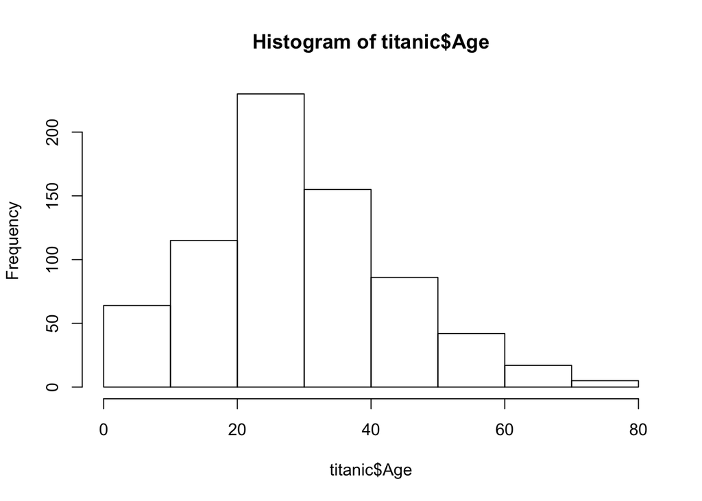

```r
# Generate histogram of Age column
hist(titanic$Age)
```

## Exploratory queries

```r
# Print out total value of fares
str(titanic)
```

```
## 'data.frame':    891 obs. of  12 variables:
##  $ PassengerId: int  1 2 3 4 5 6 7 8 9 10 ...
##  $ Survived   : int  0 1 1 1 0 0 0 0 1 1 ...
##  $ Pclass     : int  3 1 3 1 3 3 1 3 3 2 ...
##  $ Name       : Factor w/ 891 levels "Abbing, Mr. Anthony",..: 109 191 354 273 16 555 516 625 413 577 ...
##  $ Sex        : Factor w/ 2 levels "female","male": 2 1 1 1 2 2 2 2 1 1 ...
##  $ Age        : num  22 38 26 35 35 NA 54 2 27 14 ...
##  $ SibSp      : int  1 1 0 1 0 0 0 3 0 1 ...
##  $ Parch      : int  0 0 0 0 0 0 0 1 2 0 ...
##  $ Ticket     : Factor w/ 681 levels "110152","110413",..: 524 597 670 50 473 276 86 396 345 133 ...
##  $ Fare       : num  7.25 71.28 7.92 53.1 8.05 ...
##  $ Cabin      : Factor w/ 148 levels "","A10","A14",..: 1 83 1 57 1 1 131 1 1 1 ...
##  $ Embarked   : Factor w/ 4 levels "","C","Q","S": 4 2 4 4 4 3 4 4 4 2 ...
```

```r
sum(titanic$Fare)
```

```
## [1] 28693.95
```

```r
# Print out proportion of passengers that survived
mean(titanic$Survived)
```

```
## [1] 0.3838384
```

## Infer gender from names(1)

```r
# Extract the name column from titanic
pass_names <- titanic$Name

# Create the logical vectror is_man
is_man <- grepl(", Mr\\.", pass_names)

# Count the number of men
sum(is_man)
```

```
## [1] 517
```

```r
# Count number of men based on gender
sum(titanic$Sex == "male")
```

```
## [1] 577
```

## Infer gender from names(2)

```r
# Extract the name column from titanic
pass_names <- titanic$Name

# Create titles
titles <- gsub("^.*, (.*?)\\..*$", "\\1", pass_names)

# Call unique() on titles
unique(titles)
```

```
##  [1] "Mr"           "Mrs"          "Miss"         "Master"       "Don"          "Rev"
##  [7] "Dr"           "Mme"          "Ms"           "Major"        "Lady"         "Sir"
## [13] "Mlle"         "Col"          "Capt"         "the Countess" "Jonkheer"
```

## Infer gender from names(3)

```r
pass_names <- titanic$Name
titles_male <- paste(",", c("Mr\\.", "Master", "Don", "Rev", "Dr\\.", "Major", "Sir", "Col", "Capt", "Jonkheer"))

# Finish the vapply() command
hits <- vapply(titles_male,
               FUN = grepl,
               FUN.VALUE = logical(length(pass_names)),
               pass_names)

# Calculate the sum() of hits
sum(hits)
```

```
## [1] 578
```

```r
# Count number of men based on gender
sum(titanic$Sex == "male")
```

```
## [1] 577
```

### Why is it off by one?

- They don’t really address this in the class
- But one function I use a lot is the `table` function
- It easily shows whats off with the title assumptions and the gender
  - There is a female doctor on the boat but they are counting Dr as a male title
  - Definitely need to be careful with things like this. Other titles could go eaither way.

```r
table(titles, titanic$Sex)
```

```
##
## titles         female male
##   Capt              0    1
##   Col               0    2
##   Don               0    1
##   Dr                1    6
##   Jonkheer          0    1
##   Lady              1    0
##   Major             0    2
##   Master            0   40
##   Miss            182    0
##   Mlle              2    0
##   Mme               1    0
##   Mr                0  517
##   Mrs             125    0
##   Ms                1    0
##   Rev               0    6
##   Sir               0    1
##   the Countess      1    0
```

## Reformat passenger names

- this is some great regex

```r
# pass_names is available in your workspace

convert_name <- function(name) {
  # women: take name from inside parentheses
  if (grepl("\\(.*?\\)", name)) {
    gsub("^.*?\\((.*?)\\)$", "\\1", name)
  # men: take name before comma and after title
  } else {
    # Finish the gsub() function
    gsub("^(.*?),\\s[a-zA-Z\\.]*?\\s(.*?)$", "\\2 \\1", name)
  }
}

# Call convert_name on name
clean_pass_names <- vapply(pass_names, FUN = convert_name,
                           FUN.VALUE = character(1), USE.NAMES = FALSE)

# Print out clean_pass_names
head(clean_pass_names, 20)
```

```
##  [1] "Owen Harris Braund"               "Florence Briggs Thayer"
##  [3] "Laina Heikkinen"                  "Lily May Peel"
##  [5] "William Henry Allen"              "James Moran"
##  [7] "Timothy J McCarthy"               "Gosta Leonard Palsson"
##  [9] "Elisabeth Vilhelmina Berg"        "Adele Achem"
## [11] "Marguerite Rut Sandstrom"         "Elizabeth Bonnell"
## [13] "William Henry Saundercock"        "Anders Johan Andersson"
## [15] "Hulda Amanda Adolfina Vestrom"    "Hewlett, Mrs. (Mary D Kingcome) "
## [17] "Eugene Rice"                      "Charles Eugene Williams"
## [19] "Emelia Maria Vandemoortele"       "Fatima Masselmani"
```

## Add birth dates

- I’m adding the dob data manually
- the `strptime` function documentation has all the codes for matching dates

```r
# Have a look at head() of dob1 and dob2
head(dob1)
```

```
## [1] "1890-01-03" "1874-02-28" "1886-01-17" "1877-03-04" "1876-09-28" NA
```

```r
head(dob2)
```

```
## [1] "November 26, 1872"  "September 09, 1885" "September 09, 1890" "April 01, 1884"
## [5] "August 08, 1891"    "April 20, 1877"
```

```r
# Convert dob1 to dob1d, convert dob2 to dob2d
dob1d <- as.Date(dob1, '%Y-%m-%d')

dob2d <- as.Date(dob2, '%b %d, %Y')

# Combine dob1d and dob2d into single vector: birth_dates
birth_dates <- c(dob1d,dob2d)
```

## Average age

- I have not used subset in a while. Just use `dplyr::filter` now

```r
# titanic, dob1 and dob2 are preloaded
dob1d <- as.Date(dob1)
dob2d <- as.Date(dob2, format = "%B %d, %Y")
birth_dates <- c(dob1d, dob2d)
disaster_date <- as.Date("1912-04-15")

# Add birth_dates to titanic (column Birth)
titanic$Birth <- birth_dates
str(titanic)
```

```
## 'data.frame':    891 obs. of  13 variables:
##  $ PassengerId: int  1 2 3 4 5 6 7 8 9 10 ...
##  $ Survived   : int  0 1 1 1 0 0 0 0 1 1 ...
##  $ Pclass     : int  3 1 3 1 3 3 1 3 3 2 ...
##  $ Name       : Factor w/ 891 levels "Abbing, Mr. Anthony",..: 109 191 354 273 16 555 516 625 413 577 ...
##  $ Sex        : Factor w/ 2 levels "female","male": 2 1 1 1 2 2 2 2 1 1 ...
##  $ Age        : num  22 38 26 35 35 NA 54 2 27 14 ...
##  $ SibSp      : int  1 1 0 1 0 0 0 3 0 1 ...
##  $ Parch      : int  0 0 0 0 0 0 0 1 2 0 ...
##  $ Ticket     : Factor w/ 681 levels "110152","110413",..: 524 597 670 50 473 276 86 396 345 133 ...
##  $ Fare       : num  7.25 71.28 7.92 53.1 8.05 ...
##  $ Cabin      : Factor w/ 148 levels "","A10","A14",..: 1 83 1 57 1 1 131 1 1 1 ...
##  $ Embarked   : Factor w/ 4 levels "","C","Q","S": 4 2 4 4 4 3 4 4 4 2 ...
##  $ Birth      : Date, format: "1890-01-03" "1874-02-28" "1886-01-17" ...
```

```r
# Create subset: survivors
survivors <- subset(titanic, Survived == TRUE)
str(survivors)
```

```
## 'data.frame':    342 obs. of  13 variables:
##  $ PassengerId: int  2 3 4 9 10 11 12 16 18 20 ...
##  $ Survived   : int  1 1 1 1 1 1 1 1 1 1 ...
##  $ Pclass     : int  1 3 1 3 2 3 1 2 2 3 ...
##  $ Name       : Factor w/ 891 levels "Abbing, Mr. Anthony",..: 191 354 273 413 577 728 96 360 868 513 ...
##  $ Sex        : Factor w/ 2 levels "female","male": 1 1 1 1 1 1 1 1 2 1 ...
##  $ Age        : num  38 26 35 27 14 4 58 55 NA NA ...
##  $ SibSp      : int  1 0 1 0 1 1 0 0 0 0 ...
##  $ Parch      : int  0 0 0 2 0 1 0 0 0 0 ...
##  $ Ticket     : Factor w/ 681 levels "110152","110413",..: 597 670 50 345 133 617 39 154 152 185 ...
##  $ Fare       : num  71.28 7.92 53.1 11.13 30.07 ...
##  $ Cabin      : Factor w/ 148 levels "","A10","A14",..: 83 1 57 1 1 147 51 1 1 1 ...
##  $ Embarked   : Factor w/ 4 levels "","C","Q","S": 2 4 4 4 2 4 4 4 4 2 ...
##  $ Birth      : Date, format: "1874-02-28" "1886-01-17" "1877-03-04" ...
```

```r
# Calculate average age of survivors
mean(disaster_date - survivors$Birth, na.rm=T)
```

```
## Time difference of 10532.41 days
```

## Age in perspective

```r
## How old was the youngest survivor when Apollo 11 landed on the moon on July 20, 1969?

min(as.Date('1969-07-20') - survivors$Birth, na.rm=T)
```

```
## Time difference of 21285 days
```

# Conclusion

- This is great practice for the skillsets
- I do think a lot of data analsyis is made simpler with the use of dataframes
- The dplyr, tidyr, and other libraries replace a lot of the disparate R functions around data crunching into a clean and consistent grammar
  - There are courses on these topics later in the Data Science Track
- A lot of this is core data crunching skills or even just programming skills that are needed in any language really so this is a good class for anyone getting into programing
  - But I would caution that there are much smoother ways to work with data in R. Its really what makes R so great. It has the best libraries I think.
  - I’m looking forward to covering more of the library functions in docs like this soon.